# Tarea1-TomásRicardoBasile

### 1

**Una compañía telefónica registra los números de una ciudad en 3 zonas:**

**1. La zona A la conforman aquellos números que son divisibles entre 5**

**2. La Zona B aquellos que son divisibles entre números pares.**

**3. La Zona C aquellos que son divisibles entre números impares.**

**Un descuidado empleado ha revuelto los 2 mil números de la ciudad, y necesita ayuda para reorganizar las listas.**

**Ejecuta el siguiente código para obtener la lista de los números telefónicos tras el descuido del empleado.**

```python
from random import *

numeros_ciudad = []
# Lista que tendrá los nímeros de la ciudad
for i in range(5000):
    if len(numeros_ciudad)==2000:
        # si ya escribimos 2000 numeros, le paramos
        break
    else:
        #sino, creamos un numero aleatorio, usando una semilla distinta
        semilla = i**2
        seed(semilla)
        numero = randint(64350000, 64390000)
        # siempre y cuando el nuevo número no esté ya registrado
        if numero not in numeros_ciudad:
            numeros_ciudad.append(numero)

print(numeros_ciudad)
```

```
[64375247, 64358805, 64365469, 64380343, 64373692, 64374704, 64371541, 64354383, 64381205, 64383157, 64359546, 64355721, 64379377, 64366746, 64383257, 64365694, 64382037, 64367841, 64388672, 64358542, 64370164, 64361650, 64387480, 64359976, 64388509, 64376795, 64351968, 64371448, 64378364, 64387859,…
```

**a) Organiza los números telefónicos en tres listas de acuerdo a su zona.**

```python
"""vamos a iterar sobre todos los números de teléfono para irlos agregando
a sus respectivas zonas. Y de tal forma que cada número quede en una sola zona.

Por ello, primero checaré los números que entran a la zona A.
Luego, sólo si no entran a la zona A, checaré si entran a la B.
Y finalmente, si no entran a la A ni a la B, checaré si entran a la C.
Así tendremos tres zonas que no se intersecten.
"""

# Creamos listas vacías donde iremos guardando los números de cada zona
zonaA = []
zonaB = []
zonaC = []

# vamos iterando sobre los numeros
for num in numeros_ciudad:
    # si el número es divisible por 5 (tiene residuo 0 al dividir por 5)
    if num % 5 == 0:
        # lo metemos en la zona A
        zonaA.append(num)

    # si no lo hemos metido a la lista A, checamos si es divisible por un par
    # todos los números divisibles por un par son divisibles en particular por 2
    # Este código sólo se corre si el número no entró a A
    elif num % 2 == 0:
        zonaB.append(num)

    # Si no entra en ninguna de estas listas, significa que no es
    # divisible por 2 (y por tanto por ningún número par)
    # y entonces debe de ser divisible sólo por impares
    # por eso usamos else, porque todos los números restantes deben pertenecer
    # a C
    else:
        zonaC.append(num)



# para revisar un poco las listas, imprimimos los primeros elementos
print('algunos de la zonaA', zonaA[:5])
print('algunos de la zonaB',zonaB[:5])
print('algunos de la zonaC',zonaC[:5])

# para convencernos de que no se intersectan ni dejamos ningún número fuera
# vemos cuántos números hay entre las 3 listas (deberían ser 2000)
print(len(zonaA)+len(zonaB)+len(zonaC))
```

```
algunos de la zonaA [64358805, 64381205, 64361650, 64387480, 64376795]
algunos de la zonaB [64373692, 64374704, 64359546, 64366746, 64365694]
algunos de la zonaC [64375247, 64365469, 64380343, 64371541, 64354383]
2000
```

**b) Días después de ordenar los números, el dueño de una cadena de pizzerías ha decidido mover sus tiendas de la Zona A a la Zona C. La compañía ha decidido conservar los números telefónicos, y necesita pasar los números de la lista de la Zona A a la lista de la Zona C.**

**Los números de la cadena de pizzerías se caracterizan por empezar con los dígitos 64358. Realiza el reacomodo, pasando cada los números de las pizzerías de la lista de la Zona A a la lista de la Zona C. Imprime la cantidad de pizzerías que hay en la ciudad y el número de cada una de ellas.**

**Opcionalmente te sugerimos los siguientes pasos**

**1. Realiza un bucle para analizar los elementos de la Zona A, una vez dentro del bucle convierte los números en valores string.**

**2. Hecho esto compara los primeros 5 números con los dígitos característicos de las pizzerías. Los dígitos de las pizzerías también deben ser valores string.**

**3. Localizado un número de las pizzerías, elimínalo de la lista de la Zona A y agrégalo a la lista de la Zona C**

```python
#Vamos a iniciar el contador de pizzerías totales en 0
tot = 0
# y la lista donde guardaremos los números de teléfono
pizzerias=[]


# vamos iterando sobre los números e índices de la zonaA

for i, num in enumerate(zonaA):
    # convertimos a string el num y así sacamos los primeros 5 dígitos
    # y le llamamos digs5 a estos dígitos
    digs5 = str(num)[:5]

    # checamos si cumple con la condición para ser una pizzería
    # estos 5 dígitos tendrían que ser 64358
    if digs5 == '64358':
        # sacamos el número de la zona A
        zonaA.pop(i)
        # lo agregamos a la zona C y a nuestra lista de pizzerías
        zonaC.append(num)
        pizzerias.append(num)
        # aumentamos en 1 el contador
        tot+=1
print('Cantidad total de pizzerias:', tot)
print('Números de las pizzerias:', pizzerias)

# checamos que no hayamos duplicado ningún número ni borrado totalmente uno
# la cantidad total de números de las 3 listas tiene que seguir siendo 2000
print(len(zonaA)+len(zonaB)+len(zonaC))
```

```
Cantidad total de pizzerias: 14
Números de las pizzerias: [64358805, 64358500, 64358830, 64358465, 64358375, 64358990, 64358200, 64358910, 64358965, 64358240, 64358150, 64358345, 64358645, 64358820]
2000
```

# 2

**Escribir un programa que almacene las calificaciones de un semestre en el diccionario ’Electromagnetismo’: 10, ’Electrónica’: 9, ’Relatividad’: 8,’Física Computacional’: 10, ’Física Estadística’: 9, y después muestre por pantalla las calificaciones de cada asignatura en el formato asignatura como Key y calificacion como valor del Key. Al final debe mostrar también el promedio del semestre.**

```python
import numpy as np
calificaciones={} # creamos un diccionario vacío

#le vamos agregando las materias y calificaciones
calificaciones['Electromagnetismo']=10
calificaciones['Electrónica']=9
calificaciones['Física Computacional']=10
calificaciones['Física Estadística']=9

# imprimimos el diccionario para ver que esté bien
print(calificaciones)


#Ahora vamos a imprimir una por una las materias y calificaciones
# iteramos sobre las keys del diccionario
for key in calificaciones:
    # Imprimimos la key (el nombre de la materia)
    # y la entrada (la calificación en la materia)
    print("En la materia" ,key, "obtuvo una calificación de"
          ,calificaciones[key])

# Para calcular el promedio



# incializamos una variable "tot" igual a 0 en donde sumaremos el total de las
# calificaciones
tot = 0
#Iteramos sobre los valores del diccionario (las calificaciones)

for valor in calificaciones.values():
    #Vamos sumando al total
    tot+=valor
# El promedio es el total dividido entre la cantidad total de calificaciones
# Que es len(calificacoines)
print('Un promedio de', tot/len(calificaciones))
```

```
{'Electromagnetismo': 10, 'Electrónica': 9, 'Física Computacional': 10, 'Física Estadística': 9}
En la materia Electromagnetismo obtuvo una calificación de 10
En la materia Electrónica obtuvo una calificación de 9
En la materia Física Computacional obtuvo una calificación de 10
En la materia Física Estadística obtuvo una calificación de 9
Un promedio de 9.5
```

# 3

**Un satélite se encuentra en una órbita circular alrededor de la Tierra, tal que completa un círculo en T segundos, T es el periodo de la órbita:**

**1. Muestra que la altitud h sobre la superficie de la Tierra será:**

$ h = \left( \dfrac{GMT^2}{4 \pi^2} \right)^{1/3} - R$

**donde G es la constante de gravitación universal con valor G = 6.67×10−11 $m^3kg^{-1}s^{-2}$, M es la masa de la Tierra M = 5.97 × 1024kg y R es el radio de la Tierra R = 6371 km.**

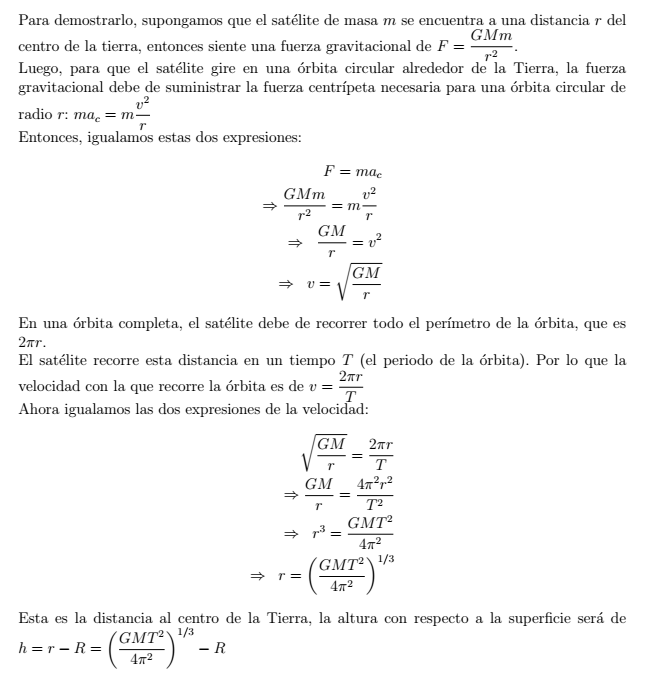

**2. Escribe un programa que le pregunte al usuario el periodo que desea tenga su satélite girando alrededor de la Tierra y el programa le regrese la altitud, en metros, que deberá tener.**

```python
from math import pi

#Definimos una función que toma un tiempo T y nos da la altura
def altura(T):
    G = 6.67*10**(-11)
    M = 5.97*10**24
    R = 6371*10**3

    #Aplicamos la ecuación que acabamos de deducir

    h = (G*M*T**2/(4*pi**2))**(1/3)-R

    #Si el resultado es negativo, no tiene sentido, pues sería un radio menor al de la Tierra

    if h < 0:
        #Así que imprimimos un mensaje de error
        return(str(round(h))+' metros. Órbita imposible, demasiado rápida, requiere orbitar debajo de la superficie')
    #regresamos el valor h redondeado
    return(round(h))

# Pedimos el tiempo como un input
T = input('Introduzca el periodo que desea que tenga su satélite (en segundos): ')

#Para asegurarnos que introduzcan un número y no otra cosa
#Iniciamos un loop infinito
while True:
    try:
        #Probamos si es posible transformar T en float
        # Si se puede, significa que nos dieron un input con data type válido
        # Así que cortamos el loop
        T = float(T)
        break
    #Si hay un error, mandamos un mensaje de error y volvemos a pedir un input
    except ValueError:
        print('Su entrada no es válida, introduzca un número')
        T = input('Introduzca el periodo que desea que tenga su satélite (en segundos): ')


h = altura(T)
print('Altura del satelite:', h, 'metros sobre la superficie')
```

```
Introduzca el periodo que desea que tenga su satélite (en segundos): 99999
Altura del satelite: 40178024 metros sobre la superficie
```

**3. ¿Qué altitud deberá tener el satélite si queremos que orbite la Tierra con un periodo de un día (órbita geosíncrona), 90 minutos, 45 minutos? ¿Qué observas?**

```python
# Calculamos la altura para cada caso usando la función

#Para la primera, usamos un periodo de 24 horas (24*60*60 segundos)
h1 = altura(24*60*60)

# Para la segunda un periodo de 90 minutos
h2 = altura(90*60)

# Y finalmente uno de 45
h3 = altura(45*60)


print('Altitud para órbita geosíncrona:', h1, 'metros')
print('Altitud para periodo de 90 min:', h2,'metros')
print('Altitud para periodo de 45 min:', h3)
```

```
Altitud para órbita geosíncrona: 35855910 metros
Altitud para periodo de 90 min: 279322 metros
Altitud para periodo de 45 min: -2181560 metros. Órbita imposible, demasiado rápida, requiere orbitar debajo de la superficie
```

Vemos que la órbita geosíncrona es bastante lejana (a casi 36,000 km)

La órbita de 90 minutos es a 280km de la superficie, un poco menos que la distancia a la que orbitan la mayoría de los satélites de low orbit (la estación espacial orbita a 410km, Hubble a 540 km, etc.)

La órbita de 45 minutos es imposible de lograr, pues requeriría un radio de 2181 km por debajo de la superficie de la Tierra.

**4. En práctica, una órbita geosíncrona es aquella cuya órbita tiene un periodo de un día sideral, que es de 23.93 horas, no de 24 horas. ¿Por qué es esto? ¿Cuál será la diferencia en altitud entre T= 23.93 horas y T= 24 horas.**

Esto se debe a que la Tierra da una vuelta alrededor de su eje en 23.93 horas (día sideral), no 24 horas. Lo que pasa es que cuando la Tierra da una vuelta completa alrededor de su eje, se mueve un poco en su órbita alrededor del sol. Por lo que después de las 23.93 horas de un día sideral, a la Tierra todavía le falta rotar un poco para tener la misma orientación con respecto al sol. Esto se puede apreciar claramente en la imagen:

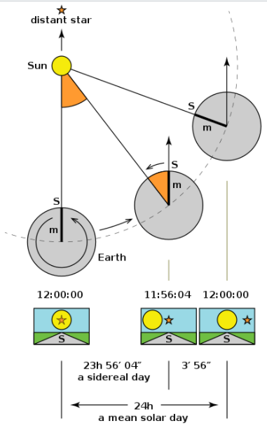

Imagen tomada de : https://upload.wikimedia.org/wikipedia/commons/thumb/d/d0/Sidereal_time.svg/800px-Sidereal_time.svg.png

Cuando estamos en la superficie de la Tierra, medimos un día solar como el lapso que tarda desde que el Sol está en el punto más alto sobre el horizonte hasta que vuelve a estarlo. Es decir, el día sideral es el tiempo en dar una rotación mientras que el día solar es el tiempo en volver a la misma alineación con el sol, y no son lo mismo. Por ello, y como vemos en la imagen, un día solar es un poco más largo que el día sideral.

Si queremos que el satélite se mantenga siempre sobre la misma ubicación de la Tierra, el satélite debe de tener un periodo igual al de la rotación de la Tierra (día sideral), es decir, 23.93 horas.

```python
# Calculamos la cantidad de segundos de un día sideral y le aplicamos la
# función para obtener la altura
h4 = altura(23.93*60*60)
print('Altitud para órbita geosíncrona (bien calculada):', h4, 'metros')
print('Altitud para órbita geosíncrona (mal calculada, usando día solar)',
      h1, 'metros')
print('Diferencia de altitudes', h1-h4, 'metros')
```

```
Altitud para órbita geosíncrona (bien calculada): 35773762 metros
Altitud para órbita geosíncrona (mal calculada, usando día solar) 35855910 metros
Diferencia de altitudes 82148 metros
```

Es decir, si usamos una órbita basada en el día solar en vez del día sideral, pondremos nuestro satélite 82 km más arriba de lo que deberíamos.

# 4 Algoritmo de Fracciones continuas

**Para la solución de ecuaciones cuadráticas, en ocasiones se tienen fuertes singularidades y la fórmula ya no es funcional. Una manera de darle la vuelta a estas singularidades es reescribir la ecuación a evaluar en términos de una expansión Taylor. Otra posibilidad es utilizar las llamadas fracciones continuas, que pueden verse como generalizaciones de una expansión de Taylor. Un enfoque posible de las fracciones continuas es la sustitución sucesiva. Vamos a ilustrar esto con un ejemplo simple:**

$x^2 + 4x-1=0$

que puede reescribirse como:

$x = \dfrac{1}{4+x}$

que, a su vez, podría representarse a través de un proceso iterativo de sustitución:

$x_{n+1} = \dfrac{1}{4+x_n}$

con $x_0 = 0$. Esto significa que si tenemos: $x_1 = \dfrac{1}{4}$ $x_2 = \dfrac{1}{4+ \dfrac{1}{4}}$ $x_3 = \dfrac{1}{4+ \dfrac{1}{\dfrac{1}{4}}}$

Esto puede ser reescrito de forma compacta como:

[figure not shown]

**1. Escribe un programa que resuelve la ecuación (1) con la implementación del algoritmo de fracción continua y resuelva iterativamente. La solución exacta es x = 0.23607** **¿Cuántas iteraciones necesitamos para tener 3 cifras decimales correctas?**

```python
# Vamos a definir una función que toma x_n y nos da x_{n+1}
# Para ello usamos la función iterativa que nos da el enunciado

#Toma como entrada un número x
def siguiente(x):
    # Le aplica la función que vimos 1/(4+x)
    y = 1/(4+x)
    # Regresa el resultado
    return(y)

# Definimos la función iterar, que va a realizar toda la iteración hasta
# Llegar a la precisión deseada

# La función toma dos entradas, el valor de x inicial y la precisión que queremos
def iterar(x,e=1e-3):
    #inicializamos el contador
    contador = 0
    # Calculamos el primer siguiente elemento de la sucesión
    xn = siguiente(x)
    # Y aumentamos el contador porque ya hicimos un paso
    contador += 1

    # Ahora, mientras la diferencia entre un valor y el siguiente
    # Sea mayor al error deseado
    while abs(xn-x)>e:
        # El x siguiente pasa a ser el x actual
        x = xn

        # Y calculamos el siguiente elemento de la sucesión después de xn
        xn = siguiente(xn)
        # Vamos aumentando el contador
        contador+=1
    # Regresamos el último valor de la secuencia y el contador
    return([xn,contador])

# Calculamos el resultado de empezar desde 0 la iteración
# Con una precisión de 0.001
res = iterar(0,1e-3)

print('Resultado final:', res[0])
print('Cantidad de pasos:', res[1])
```

[output not shown]

```python
# También podemos calcular la cantidad de pasos para distintas precisiones
import pandas as pd
Precision_Buscada = []
Raiz_Encontrada = []
lista_incremental=[]

valor_real=0.236067977499790 #valor real con 15 decimales
for i in range(1,15):
    e = 10**(-i)
    Precision_Buscada.append(e)
    res=iterar(0,e) #cada renglon de la tabla

    lista_incremental.append([e,str(res[0]),res[1]])
cols = ["Precisión Buscada","Raíz encontrada","Número de pasos"]
a=pd.DataFrame(lista_incremental, columns=cols)
a.set_index("Precisión Buscada")
```

| Precisión Buscada | Raíz encontrada | Número de pasos |
| --- | --- | --- |
| 1.000000e-01 | 0.23529411764705882 | 2 |
| 1.000000e-02 | 0.2361111111111111 | 3 |
| 1.000000e-03 | 0.2361111111111111 | 3 |
| 1.000000e-04 | 0.23606557377049184 | 4 |
| 1.000000e-05 | 0.23606811145510836 | 5 |
| 1.000000e-06 | 0.23606797003471586 | 6 |
| 1.000000e-07 | 0.236067977915804 | 7 |
| 1.000000e-08 | 0.236067977915804 | 7 |
| 1.000000e-09 | 0.23606797747660604 | 8 |
| 1.000000e-10 | 0.2360679775010817 | 9 |
| 1.000000e-11 | 0.23606797749971767 | 10 |
| 1.000000e-12 | 0.2360679774997937 | 11 |
| 1.000000e-13 | 0.2360679774997937 | 11 |
| 1.000000e-14 | 0.2360679774997895 | 12 |

Vemos que la cantidad de pasos necesarios se mantiene chica incluso para precisiones muy altas.

**2.Generaliza el código para que el usuario introduzca los coeficientes de la función y el número de precisión que desea obtener.**

Supongamos que la ecuación de segundo grado es de la forma: $ax^2 + bx + c = 0$

Entonces, se tiene que $ax^2+bx = -c$  
Por lo que $x(ax+b) = -c$ y entonces $x = \dfrac{-c}{ax+b}$

Por lo que la fórmula recursiva es: $x_{n+1} = \dfrac{-c}{ax_n+b}$

Ahora implementamos este método de una forma muy similar a la parte anterior

```python
# Vamos a definir una función que toma x_n y nos da x_{n+1}
# Para ello usamos la función iterativa que encontramos. Que depende
# de los tres parámetros a,b,c

#Toma como entrada un número x y los parámetros a,b,c
def siguiente(x,a,b,c):
    # Le aplica la función que vimos iterativa que vimos
    y = -c/(a*x+b)
    # Regresa el resultado
    return(y)

# Definimos la función iterar similar a la del ejercicio anterior
# Pero ahora también toma los coeficientes a,b,c como entradas

#x es el valor inicial que proponemos como raíz
def iterar(x,a,b,c,e=1e-6):
    # Si x inicial es -b/a, la función siguiente va a tener que dividir entre 0
    # por lo que cambiamos levemente el x
    if x == -b/a:
        x+=0.1

    # inicializamos el contador
    contador = 0
    # Calculamos el primer siguiente de la lista
    xn = siguiente(x,a,b,c)
    contador+=1

    # mientras el error entre un valor y el siguiente sea mayor al error deseado
    # Agregamos también un límite al contador (de 2000 en este caso)
    # para que no itere sin parar si no está convergiendo
    while abs(xn-x)>e and contador < 2000:
        # el x siguiente pasa a ser el actual
        x = xn
        # calculamos el siguiente elemento y aumentamos el contador
        xn = siguiente(xn,a,b,c)
        contador+=1

    # Al terminar el while, si la secuencia logró converger (no se pasó del límite)
    if contador <2000:
        # regresamos el último valor y el contador
        return([xn,contador])
    # Si la secuencia no converge, imprimimos un mensaje de error
    else:
        print("""El método no converge con la precisión requerida en el número de pasos usados. Quizá la función no tiene soluciones reales""")
        print("Imprimimos el último número en la sucesión y el contador")
        return([xn,contador])
```

Por ejemplo, calculamos ahora la raíz de la misma función de antes $x^2 + 4x-1=0$

Y para ponerlo un poco más a prueba, calculamos también las raíces de $2x^2 + 8x - 5 =0$ que son -4.549509757 y 0.5495097568 (convergeremos a alguna de las dos)

```python
# para la función x^2 + 4x - 1 =0
# Aplicamos la iteración con una precisión de 10^(-6) empezando en x=0

res1 = iterar(0,1,4,-1,1e-6)
print('Raíz de x^2 + 4x-1: ', res1[0])
print('Número de iteraciones: ', res1[1])
print('\n')

# para la función 2x^2 + 8x - 5 = 0
# Aplicamos la iteración con una precisión de 10^(-6) empezando en x=0

res2 = iterar(0,2,8,-5,1e-6)
print('Raíz de 2x^2 + 8x-5: ', res2[0])
print('Número de iteraciones: ', res2[1])

# y ahora para una que no va a converger (porque tiene raices imaginarias)
# x^2 + 1 = 0

print('\n')
res3 = iterar(0,1,0,-1,1e-6)
print(res3)
```

```
Raíz de x^2 + 4x-1:  0.23606797003471586
Número de iteraciones:  6


Raíz de 2x^2 + 8x-5:  0.5495097288976943
Número de iteraciones:  8


El método no converge con la precisión requerida en el número de pasos usados. Quizá la función no tiene soluciones reales
Imprimimos el último número en la sucesión y el contador
[0.1, 2000]
```

Sobre la convergencia de este método, Euler probó un teorema general para saber si el método converge o no.

Si la función es $ax^2 + bx + c =0$, distinguimos varios casos:

1. Si b = 0, la secuencia no converge
2. Si $b \neq 0$ y el discriminante $\sqrt{b^2-4ac}$ es negativo, la secuencia diverge (pues no puede converger a una raíz ya que ambas son imaginarias)
3. Si $b \neq 0$ y el discriminante es 0, la secuencia converge a la única raíz de multiplicidad 2
4. Si $b \neq 0$ y el discriminante es positivo, la secuencia converge a alguna de ellas

# 5

**Escribe una función que reciba una matriz y regrese la matriz transpuesta**

```python
from numpy import *

# Definimos la función
def transpuesta(A):
    # contamos el número de renglones y columnas de la matriz
    ren_A = len(A)
    col_A = len(A[0,:])

    # Inicializamos una nueva matriz con las dimensiones al revés
    # y del mismo tipo que A
    AT = zeros([col_A,ren_A],A.dtype)

    # Iteramos sobre las posiciones de nuestra nueva matriz AT
    for i in range(col_A):
        for j in range(ren_A):
            # El valor de AT en [i,j] es igual al de A en [j,i]
            AT[i,j] = A[j,i]
    # Regresamos el resultado
    return(AT)


#ponemos a prueba
A = array([[1.33,2,3],[4,5,6]])
print('matriz de prueba \n',A)
print('resultado \n', transpuesta(A))
```

```
matriz de prueba
 [[1.33 2.   3.  ]
 [4.   5.   6.  ]]
resultado
 [[1.33 4.  ]
 [2.   5.  ]
 [3.   6.  ]]
```

# 6.

**Escribe una función que reciba una matriz compleja y regrese la matriz compleja conjugada**

```python
# Importamos de nuevo numpy por si no fue corrida la celda anterior
from numpy import *

# Definimos la función
def conjugada(A):

    # Contamos el número de renglones y columnas
    ren_A = len(A)
    col_A = len(A[0,:])

    # Creamos nuestra matriz resultado, con la misma dimensión y tipo
    res = zeros([ren_A,col_A],A.dtype)

    # Vamos iterando sobre las posiciones de la matriz
    for i in range(ren_A):
        for j in range(col_A):
            # El elemento i,j de la nueva matriz es el conjugado de la actual
            # usamos la función conjugate que viene en numpy
            res[i,j] = conjugate(A[i,j])

    return(res)

# Lo ponemos a prueba
A = array([[1j,2+1j,3+1j],[4-4j,5-1j,6-7j]])
print('matriz de prueba \n', A)
print('matriz conjugada \n', conjugada(A))
print('matriz conjugada transpuesta \n', transpuesta(conjugada(A)))
```

```
matriz de prueba
 [[0.+1.j 2.+1.j 3.+1.j]
 [4.-4.j 5.-1.j 6.-7.j]]
matriz conjugada
 [[0.-1.j 2.-1.j 3.-1.j]
 [4.+4.j 5.+1.j 6.+7.j]]
matriz conjugada transpuesta
 [[0.-1.j 4.+4.j]
 [2.-1.j 5.+1.j]
 [3.-1.j 6.+7.j]]
```

# 7.

**Escribe una función que reciba dos matrices y regrese la suma matricial.**

```python
# Importamos de nuevo numpy por si no fue corrida la celda anterior
from numpy import *


# Definimos la función que toma dos matrices
def suma(A,B):
    # Calculamos las dimensiones de las matrices
    ren_A = len(A)
    col_A = len(A[0,:])
    ren_B = len(B)
    col_B = len(B[0,:])


    # Si las dimensiones de las matrices no coinciden
    # no se puede realizar la operación, regresamos un mensaje de error
    if ren_A != ren_B or col_A != col_B:
        return('No es posible hacer la suma, las dimensiones tienen que ser iguales')

    # Creamos una matriz con las dimensiones de A
    # El tipo de esta matriz va a ser el promote_types del tipo de A y B
    # La función promote_types de numpy regresa un tipo de datos que pueda
    # contener a los tipos A.dtype y B.dtype sin alterar sus valores
    res = zeros([ren_A,col_A],promote_types(A.dtype,B.dtype))

    # Vamos iterando sobre las posiciones de la matriz
    for i in range(ren_A):
        for j in range(col_A):
            # El elemento de la matriz res es la suma de los de A y B
            res[i,j]=A[i,j]+B[i,j]
    return(res)

# Hacemos una prueba, creamos 3 matrices
A = array([[1,2,3],[4,5,6]])
B = array([[-1+1j,4,3],[1,1,7]])
# C va a tener dimensiones distintas
C = array([[1,2,3],[4,5,5],[1,1,1]])


print('matriz A: \n', A)
print('matriz B:\n', B)
print('matriz C:\n', C)
print('\n')

# Calculamos algunas sumas
print('matriz A+B: \n', suma(A,B))
print("\n")
print('matriz A+C: \n', suma(A,C))
```

```
matriz A:
 [[1 2 3]
 [4 5 6]]
matriz B:
 [[-1.+1.j  4.+0.j  3.+0.j]
 [ 1.+0.j  1.+0.j  7.+0.j]]
matriz C:
 [[1 2 3]
 [4 5 5]
 [1 1 1]]


matriz A+B:
 [[ 0.+1.j  6.+0.j  6.+0.j]
 [ 5.+0.j  6.+0.j 13.+0.j]]


matriz A+C:
 No es posible hacer la suma, las dimensiones tienen que ser iguales
```

# 8

**Escribe una función que reciba una matriz y un escalar y regrese la multiplicación del escalar por la matriz.**

```python
# Importamos de nuevo numpy por si no fue corrida la celda anterior
from numpy import *

# Definimos la función mult que toma una matriz A y un número c
def mult(A,c):
    # Calculamos las dimensiones
    ren_A = len(A)
    col_A = len(A[0,:])
    # Generamos una nueva matriz de la misma dimensión que A
    # Con el tipo que pueda contener al tipo de A y el de c
    res = zeros([ren_A,col_A],promote_types(A.dtype,type(c)))

    # Vamos iterando sobre las posiciones
    for i in range(ren_A):
        for j in range(col_A):
            # En la posición i,j ponemos el resultado de c por
            # la posición i,j de A
            res[i,j] = c*A[i,j]
    return(res)

# Ejemplo de prueba
A = array([[1+1j,2,3],[4,5,6]])
c = 3j

print('matriz A \n', A)
print('c:',c)
print('producto por c \n' ,mult(A,c) )
```

```
matriz A
 [[1.+1.j 2.+0.j 3.+0.j]
 [4.+0.j 5.+0.j 6.+0.j]]
c: 3j
producto por c
 [[-3. +3.j  0. +6.j  0. +9.j]
 [ 0.+12.j  0.+15.j  0.+18.j]]
```